# MSE Setup

Sarah Gaichas

2025-04-11

# Setup

Following the MSE vignette from Chengxue Li at https://lichengxue.github.io/whamMSE/

```r
library(wham)
library(whamMSE)

main.dir = here::here()
```

## Run the vignette exactly first, Cheng fixed! works now

This is just a test, code not run for html

```r
year_start  <- 1  # starting year in the burn-in period
year_end    <- 20  # end year in the burn-in period
MSE_years   <- 3     # number of years in the feedback loop
# Note: no need to include MSE_years in simulation-estimation

info <- generate_basic_info(n_stocks = 2,
                            n_regions = 2,
                            n_indices = 2,
                            n_fleets = 2,
                            n_seasons = 4,
                            base.years = year_start:year_end,
                            n_feedback_years = MSE_years,
                            life_history = "medium",
                            n_ages = 12,
                            #Fbar_ages = 12,
                            #recruit_model = 2,
                            F_info = list(F.year1 = 0.2, Fhist = "F-H-L", Fmax = 2, Fmin = 1, change_time = 0.5, user_F = NULL),
                            catch_info = list(catch_cv = 0.1, catch_Neff = 100),
                            index_info = list(index_cv = 0.1, index_Neff = 100, fracyr_indices = 0.625, q = 0.2),
                            fracyr_spawn = 0.625)

basic_info = info$basic_info # collect basic information
catch_info = info$catch_info # collect fleet catch information
index_info = info$index_info # collect survey information
F_info = info$F # collect fishing information

# see more details using ?generate_basic_info

basic_info <- generate_NAA_where(basic_info = basic_info, move.type = 2) # "bidirectional" movement

move <- generate_move(basic_info = basic_info, move.type = 2, move.rate = c(0.3,0.1),
                      move.re = "iid_y", move.sigma = 0.5, prior.sigma = 0.5, use.prior = TRUE)

n_stocks  <- as.integer(basic_info['n_stocks'])
n_regions <- as.integer(basic_info['n_regions'])
n_fleets  <- as.integer(basic_info['n_fleets'])
n_indices <- as.integer(basic_info['n_indices'])
n_ages    <- as.integer(basic_info['n_ages'])

# Selectivity Configuration
fleet_pars <- c(5,1)
index_pars <- c(2,1)
sel <- list(model=rep("logistic",n_fleets+n_indices),
            initial_pars=c(rep(list(fleet_pars),n_fleets),rep(list(index_pars),n_indices)))

# M Configuration
M <- list(model="constant",initial_means=array(0.2, dim = c(n_stocks,n_regions,n_ages)))

sigma      <- "rec+1"
re_cor     <- "iid"
ini.opt    <- "equilibrium" # option   <- c("age-specific-fe", "equilibrium")

# Set para. for B-H function
alpha <- 12
beta  <- 1.5e-4

# Set sigma for NAA
NAA_sig <- 0.2
sigma_vals = array(NAA_sig, dim = c(n_stocks, n_regions, n_ages)) # n_stocks x n_regions x n_ages"

# Set initial NAA for each stock
log_N1  <- rep(10, n_stocks) # Create difference between stocks
N1_pars <- generate_ini_N1(log_N1,basic_info,ini.opt)

NAA_re <- list(N1_model=rep(ini.opt,n_stocks),
               sigma=rep(sigma,n_stocks),
               cor=rep(re_cor,n_stocks),
               recruit_model = 3,
               recruit_pars = rep(list(c(alpha,beta)),n_stocks), # assume same B-H s-r functions for all stocks
               sigma_vals = sigma_vals,
               N1_pars = N1_pars)#,
               #NAA_where = basic_info$NAA_where)

# recruit_model = 1: estimating annual recruitments as fixed effects or a random walk if NAA_re$sigma specified
# recruit_model = 2: estimating a mean recruitment with annual recruitments as random effects
# recruit_model = 3: Beverton-Holt stock-recruitment with annual recruitments as random effects
# recruit_model = 4: Ricker stock-recruitment with annual recruitments as random effects

# 1. recruit_pars: a list (length = n_stocks) of vectors of initial parameters for recruitment model.
# If $recruit_model is 3 (B-H) or 4 (Ricker), parameters are "alpha" and "beta".

# 2. sigma_vals: Initial standard deviation values to use for the NAA deviations. Values are not used if recruit_model = 1
# If sigma="rec": must be a list (length = n_stocks) of single values
# If sigma="rec+1": a list (length = n_stocks) of 2 values must be specified. First is for the first age class (recruits), second is for all other ages.

input <- prepare_wham_input(basic_info = basic_info,
                            selectivity = sel,
                            M = M,
                            NAA_re = NAA_re,
                            move = move,
                            catch_info = catch_info,
                            index_info = index_info,
                            F = F_info)

random = input$random # check what processes are random effects
input$random = NULL # so inner optimization won't change simulated RE
om <- fit_wham(input, do.fit = F, do.brps = T, MakeADFun.silent = TRUE)
# Note: do.fit must be FALSE (no modeling fitting yet)

om_with_data <- update_om_fn(om, seed = 123, random = random)

assess.interval <- 3 # Note: assessment interval is 3 years, given the feedback period is 3 years, there will be only 1 assessment
base.years      <- year_start:year_end # Burn-in period
first.year      <- head(base.years,1)
terminal.year   <- tail(base.years,1)
assess.years    <- seq(terminal.year, tail(om$years,1)-assess.interval,by = assess.interval)

mods <- list() # Create a list to save MSE outputs

n_stocks = n_regions = n_fleets = n_indices = 1

sel_em <- list(model=rep("logistic",n_fleets+n_indices),
               initial_pars=c(rep(list(fleet_pars),n_fleets),rep(list(index_pars),n_indices)))

NAA_re_em <- list(N1_model="equilibrium",sigma="rec+1",cor="iid")

M_em <- list(model="constant",initial_means=array(0.2, dim = c(n_stocks,n_regions,n_ages)))

mods[[1]] = loop_through_fn(om = om_with_data,
                            em_info = info,
                            random = random,
                            M_em = M_em,
                            sel_em = sel_em,
                            NAA_re_em = NAA_re_em,
                            move_em = NULL,
                            age_comp_em = "multinomial",
                            em.opt = list(separate.em = TRUE, separate.em.type = 1,
                                          do.move = FALSE, est.move = FALSE),
                            # Please use this code:
                            aggregate_catch_info = list(n_fleets = 1,
                                                        fleet_pointer = c(1,1),
                                                        use_catch_weighted_waa=TRUE,
                                                        catch_Neff = 100,
                                                        catch_cv = 0.1),
                            # Please use this code:
                            aggregate_index_info = list(n_indices = 1,
                                                        index_pointer = c(1,1),
                                                        use_catch_weighted_waa=TRUE,
                                                        index_Neff = 100,
                                                        index_cv = 0.1),
                            assess_years = assess.years,
                            assess_interval = assess.interval,
                            base_years = base.years,
                            year.use = 20, # number of years of data you want to use in the assessment model
                            hcr = list(hcr.type = 1, hcr.opts = NULL),
                            seed = 123,
                            save.sdrep = FALSE,
                            save.last.em = TRUE)

mods[[1]]$om$rep$pred_catch # Check catch in the feedback loop
mods[[1]]$om$rep$SSB  # Check SSB in the feedback loop
```

## Modify for long-lived, Cheng fixed and now runs

Basic info for a long-lived species. Based on Wiedenmann et al. (2017), Table 3 B and C.

A long-lived species recruits at 5 years, lives to 20, mean M is 0.1, matures at 7.

Modify from https://lichengxue.github.io/whamMSE/03.Management-Strategy-Evaluation.html

Start with a 20 year burn in and 20 MSE years. First try constant low F. Then work up to complex case.

Fishing pattern is “constant” at first to get running

Now set up as in new Single Stock MSE vignette: https://lichengxue.github.io/whamMSE/11.Single-Stock-MSE.html

These are run and outputs are in the html, so it will be loooonnnng

```r
year_start  <- 1  # starting year in the burn-in period
year_end    <- 20  # end year in the burn-in period
MSE_years   <- 20     # number of years in the feedback loop
# Note: no need to include MSE_years in simulation-estimation

info <- generate_basic_info(n_stocks = 1, #2,
                            n_regions = 1, #2,
                            n_indices = 1, #2,
                            n_fleets = 1, #2,
                            n_seasons = 1, # don't need seasons
                            base.years = year_start:year_end,
                            n_feedback_years = MSE_years,
                            life_history = "long",
                            n_ages = 20,
                            # We want a bit higher F in the historical period
                            F_info = list(F.year1 = 0.1, Fhist = "constant", Fmax = 0.1, Fmin = 0.1, change_time = 0.5, user_F = NULL),
                            catch_info = list(catch_cv = 0.1, catch_Neff = 100),
                            index_info = list(index_cv = 0.1, index_Neff = 100, fracyr_indices = 0.625, q = 0.2),
                            fracyr_spawn = 0.625)

basic_info = info$basic_info # collect basic information
catch_info = info$catch_info # collect fleet catch information
index_info = info$index_info # collect survey information
F_info = info$F # collect fishing information

# see more details using ?generate_basic_info
```

Movement, do we need this? 1 stock 1 region model, turn it off

```r
basic_info <- generate_NAA_where(basic_info = basic_info, move.type = NULL) # "bidirectional" movement

move <- NULL

#move <- generate_move(basic_info = basic_info, move.type = 2, move.rate = c(0.3), #,0.1
#                     move.re = "iid_y", move.sigma = 0.5, prior.sigma = 0.5, use.prior = TRUE)
```

Adjust for 1 area 1 stock, long lived M=0.1

```r
n_stocks  <- as.integer(basic_info['n_stocks'])
n_regions <- as.integer(basic_info['n_regions'])
n_fleets  <- as.integer(basic_info['n_fleets'])
n_indices <- as.integer(basic_info['n_indices'])
n_ages    <- as.integer(basic_info['n_ages'])

# Selectivity Configuration
fleet_pars <- c(5,1)
index_pars <- c(2,1)
sel <- list(model=rep("logistic",n_fleets+n_indices),
            initial_pars=c(rep(list(fleet_pars),n_fleets),rep(list(index_pars),n_indices)))

# M Configuration
M <- list(model="constant",initial_means=array(0.1, dim = c(n_stocks,n_regions,n_ages)))
```

```r
sigma      <- "rec+1"
re_cor     <- "iid"
ini.opt    <- "equilibrium" # option   <- c("age-specific-fe", "equilibrium")

# Set para. for B-H function
alpha <- 12
beta  <- 1.5e-4

# Set sigma for NAA
NAA_sig <- 0.2
sigma_vals = array(NAA_sig, dim = c(n_stocks, n_regions, n_ages)) # n_stocks x n_regions x n_ages"

# Set initial NAA for each stock
log_N1  <- rep(10, n_stocks) # Create difference between stocks
N1_pars <- generate_ini_N1(log_N1,basic_info,ini.opt)

NAA_re <- list(N1_model=rep(ini.opt,n_stocks),
               sigma=rep(sigma,n_stocks),
               cor=rep(re_cor,n_stocks),
               recruit_model = 3,
               recruit_pars = rep(list(c(alpha,beta)),n_stocks), # assume same B-H s-r functions for all stocks
               sigma_vals = sigma_vals,
               N1_pars = N1_pars)#,
               #NAA_where = basic_info$NAA_where)

# recruit_model = 1: estimating annual recruitments as fixed effects or a random walk if NAA_re$sigma specified
# recruit_model = 2: estimating a mean recruitment with annual recruitments as random effects
# recruit_model = 3: Beverton-Holt stock-recruitment with annual recruitments as random effects
# recruit_model = 4: Ricker stock-recruitment with annual recruitments as random effects

# 1. recruit_pars: a list (length = n_stocks) of vectors of initial parameters for recruitment model.
# If $recruit_model is 3 (B-H) or 4 (Ricker), parameters are "alpha" and "beta".

# 2. sigma_vals: Initial standard deviation values to use for the NAA deviations. Values are not used if recruit_model = 1
# If sigma="rec": must be a list (length = n_stocks) of single values
# If sigma="rec+1": a list (length = n_stocks) of 2 values must be specified. First is for the first age class (recruits), second is for all other ages.
```

Make inputs for the OM

```r
 input <- prepare_wham_input(basic_info = basic_info,
                            selectivity = sel,
                            M = M,
                            NAA_re = NAA_re,
                            move = move,
                            catch_info = catch_info,
                            index_info = index_info,
                            F = F_info)
```

[output not shown]

```r
# IMPORTANT!#
# This appears to be due to the initial F value for the Newton iterations to find F40. The default value is too high for long-lived fish
input$data$FXSPR_init[] <- 0.01 # change to a low value
```

Make the OM

```r
random = input$random # check what processes are random effects
input$random = NULL # so inner optimization won't change simulated RE
om <- fit_wham(input, do.fit = F, do.brps = T, MakeADFun.silent = TRUE)
# Note: do.fit must be FALSE (no modeling fitting yet)
```

One dataset

```r
om_with_data <- update_om_fn(om, seed = 123, random = random)
```

```
##
## Now simulating data
```

Assessment specifications, every 3 years as a start, MP could be annual

```r
assess.interval <- 3 #
base.years      <- year_start:year_end # Burn-in period
first.year      <- head(base.years,1)
terminal.year   <- tail(base.years,1)
assess.years    <- seq(terminal.year, tail(om$years,1)-assess.interval,by = assess.interval)

mods <- list() # Create a list to save MSE outputs
```

Try a simple EM, looks like EM1 [here](https://lichengxue.github.io/whamMSE/03.Management-Strategy-Evaluation.html#10_Description_of_assessment_models:)

```r
# this matches the OM
# n_stocks = n_regions = n_fleets = n_indices = 1
#
# sel_em <- list(model=rep("logistic",n_fleets+n_indices),
#                initial_pars=c(rep(list(fleet_pars),n_fleets),rep(list(index_pars),n_indices)))
#
NAA_re_em <- list(N1_model="equilibrium",sigma="rec+1",cor="iid")
#
# M_em <- list(model="constant",initial_means=array(0.1, dim = c(n_stocks,n_regions,n_ages))) # this is misspecified M

mods[[1]] = loop_through_fn(om = om_with_data,
                            em_info = info,
                            random = random,
                            M_em = M, # use OM M
                            sel_em = sel, # use OM sel
                            NAA_re_em = NAA_re_em, # use rec assumed random around the mean instead, help runtime (est B-H is difficult)
                            move_em = NULL,
                            age_comp_em = "multinomial",
                            # Here is the correct code: separate.em = FALSE also works for one-area model
                            em.opt = list(separate.em = FALSE, separate.em.type = 1,
                                          do.move = FALSE, est.move = FALSE),
                            assess_years = assess.years,
                            assess_interval = assess.interval,
                            base_years = base.years,
                            year.use = 20, # number of years of data you want to use in the assessment model
                            add.years = TRUE, # extends assessment time series instead of moving window of year.use years
                            seed = 123,
                            save.sdrep = FALSE,
                            save.last.em = TRUE,
                            FXSPR_init = 0.01) # IMPORTANT!
```

[output not shown]

```
##
## Now checking convergence of assessment model...
##
## Assessment model is converged.
##
## Now generating catch advice...
##
## Harvest Control Rule type 1
```

```
## Catch Advice
##  6838.156 7222.897 7544.738
##
## Now calculating F at age in the OM given the catch advice...
##
## Now calculating fleet-specific F in year  21
```

```
##
## Fishing mortality is  0.1179354
##
## Now updating F in OM for year  21
##
## Now simulating data for year  21
##
## Now projecting data for years after  21
##
## Now calculating fleet-specific F in year  22
##
## Fishing mortality is  0.1243675
##
## Now updating F in OM for year  22
##
## Now simulating data for year  22
##
## Now projecting data for years after  22
##
## Now calculating fleet-specific F in year  23
##
## Fishing mortality is  0.1190396
##
## Now updating F in OM for year  23
##
## Now simulating data for year  23
##
## Now projecting data for years after  23
##
## Now conducting stock assessment for year 23
## [1] "start"
## [1] "basic_info"
## [1] "catch"
## [1] "indices"
## [1] "WAA"
## [1] "NAA"
## [1] "q"
## [1] "selectivity"
## [1] "age_comp"
## [1] "F"
```

[output cut: 14 more lines]

[output not shown]

```
##
## Now checking convergence of assessment model...
##
## Assessment model is converged.
##
## Now generating catch advice...
##
## Harvest Control Rule type 1
```

```
## Catch Advice
##  6836.893 7007.414 7154.918
##
## Now calculating F at age in the OM given the catch advice...
##
## Now calculating fleet-specific F in year  24
##
## Fishing mortality is  0.1106064
##
## Now updating F in OM for year  24
##
## Now simulating data for year  24
##
## Now projecting data for years after  24
##
## Now calculating fleet-specific F in year  25
##
## Fishing mortality is  0.1095269
##
## Now updating F in OM for year  25
##
## Now simulating data for year  25
##
## Now projecting data for years after  25
##
## Now calculating fleet-specific F in year  26
##
## Fishing mortality is  0.1073041
##
## Now updating F in OM for year  26
##
## Now simulating data for year  26
##
## Now projecting data for years after  26
##
## Now conducting stock assessment for year 26
## [1] "start"
## [1] "basic_info"
## [1] "catch"
## [1] "indices"
```

[output cut: 20 more lines]

[output not shown]

```
##
## Now checking convergence of assessment model...
##
## Assessment model is converged.
##
## Now generating catch advice...
##
## Harvest Control Rule type 1
```

```
## Catch Advice
##  7689.561 7744.266 7777.549
##
## Now calculating F at age in the OM given the catch advice...
##
## Now calculating fleet-specific F in year  27
##
## Fishing mortality is  0.1294166
##
## Now updating F in OM for year  27
##
## Now simulating data for year  27
##
## Now projecting data for years after  27
##
## Now calculating fleet-specific F in year  28
##
## Fishing mortality is  0.1630626
##
## Now updating F in OM for year  28
##
## Now simulating data for year  28
##
## Now projecting data for years after  28
##
## Now calculating fleet-specific F in year  29
##
## Fishing mortality is  0.1731755
##
## Now updating F in OM for year  29
##
## Now simulating data for year  29
##
## Now projecting data for years after  29
##
## Now conducting stock assessment for year 29
## [1] "start"
## [1] "basic_info"
## [1] "catch"
## [1] "indices"
```

[output cut: 20 more lines]

[output not shown]

```
##
## Now checking convergence of assessment model...
##
## Assessment model is converged.
##
## Now generating catch advice...
##
## Harvest Control Rule type 1
```

```
## Catch Advice
##  4487.402 4499.295 4499.946
##
## Now calculating F at age in the OM given the catch advice...
##
## Now calculating fleet-specific F in year  30
##
## Fishing mortality is  0.09604996
##
## Now updating F in OM for year  30
##
## Now simulating data for year  30
##
## Now projecting data for years after  30
##
## Now calculating fleet-specific F in year  31
##
## Fishing mortality is  0.1065595
##
## Now updating F in OM for year  31
##
## Now simulating data for year  31
##
## Now projecting data for years after  31
##
## Now calculating fleet-specific F in year  32
##
## Fishing mortality is  0.1120731
##
## Now updating F in OM for year  32
##
## Now simulating data for year  32
##
## Now projecting data for years after  32
##
## Now conducting stock assessment for year 32
## [1] "start"
## [1] "basic_info"
## [1] "catch"
## [1] "indices"
```

[output cut: 20 more lines]

[output not shown]

```
##
## Now checking convergence of assessment model...
##
## Assessment model is converged.
##
## Now generating catch advice...
##
## Harvest Control Rule type 1
```

```
## Catch Advice
##  4200.464 4272.023 4395.738
##
## Now calculating F at age in the OM given the catch advice...
##
## Now calculating fleet-specific F in year  33
##
## Fishing mortality is  0.1058399
##
## Now updating F in OM for year  33
##
## Now simulating data for year  33
##
## Now projecting data for years after  33
##
## Now calculating fleet-specific F in year  34
##
## Fishing mortality is  0.1223832
##
## Now updating F in OM for year  34
##
## Now simulating data for year  34
##
## Now projecting data for years after  34
##
## Now calculating fleet-specific F in year  35
##
## Fishing mortality is  0.1319956
##
## Now updating F in OM for year  35
##
## Now simulating data for year  35
##
## Now projecting data for years after  35
##
## Now conducting stock assessment for year 35
## [1] "start"
## [1] "basic_info"
## [1] "catch"
## [1] "indices"
```

[output cut: 20 more lines]

[output not shown]

```
##
## Now checking convergence of assessment model...
##
## Assessment model is converged.
##
## Now generating catch advice...
##
## Harvest Control Rule type 1
```

```
## Catch Advice
##  4293.346 4584.106 4867.559
##
## Now calculating F at age in the OM given the catch advice...
##
## Now calculating fleet-specific F in year  36
##
## Fishing mortality is  0.1154158
##
## Now updating F in OM for year  36
##
## Now simulating data for year  36
##
## Now projecting data for years after  36
##
## Now calculating fleet-specific F in year  37
##
## Fishing mortality is  0.1185013
##
## Now updating F in OM for year  37
##
## Now simulating data for year  37
##
## Now projecting data for years after  37
##
## Now calculating fleet-specific F in year  38
##
## Fishing mortality is  0.1220393
##
## Now updating F in OM for year  38
##
## Now simulating data for year  38
##
## Now projecting data for years after  38
## Please ignore Warning in check_projF(proj_mod).
## Total Runtime =  5.493558
```

Try same model with poorer survey in the future

See https://lichengxue.github.io/whamMSE/15.Reduce-Data-Availability-In-Assessment.html#6_Increase_observation_error_and_reduce_sample_size_for_survey_indices_in_the_feedback_period

```r
agg_index_sigma = input$data$agg_index_sigma
agg_index_sigma[21:40,] = 1 # Increase CV for both survey indices in the feedback period
index_Neff = input$data$index_Neff
index_Neff[21:40,] = 30 # Decrease ESS for both survey indices in the feedback period

input <- update_input_index_info(input, agg_index_sigma, index_Neff) # Update input file
```

Generate new om and dataset, keep same assessment interval as above

```r
om <- fit_wham(input, do.fit = F, do.brps = T, MakeADFun.silent = TRUE)
om_with_data <- update_om_fn(om, seed = 123, random = random)
```

```
##
## Now simulating data
```

Run new loop

```r
mods[[2]] = loop_through_fn(om = om_with_data,
                            em_info = info,
                            random = random,
                            M_em = M, # use OM M
                            sel_em = sel, # use OM sel
                            NAA_re_em = NAA_re_em, # use rec assumed random around the mean instead, help runtime (est B-H is difficult)
                            move_em = NULL,
                            age_comp_em = "multinomial",
                            # Here is the correct code: separate.em = FALSE also works for one-area model
                            em.opt = list(separate.em = FALSE, separate.em.type = 1,
                                          do.move = FALSE, est.move = FALSE),
                            assess_years = assess.years,
                            assess_interval = assess.interval,
                            base_years = base.years,
                            year.use = 20, # number of years of data you want to use in the assessment model
                            add.years = TRUE,
                            update_index_info  = list(agg_index_sigma = agg_index_sigma, index_Neff = index_Neff), # Must have this!
                            seed = 123,
                            save.sdrep = FALSE,
                            save.last.em = TRUE,
                            FXSPR_init = 0.01) # IMPORTANT!
```

[output not shown]

```
##
## Now checking convergence of assessment model...
##
## Assessment model is converged.
##
## Now generating catch advice...
##
## Harvest Control Rule type 1
```

```
## Catch Advice
##  6838.156 7222.897 7544.738
##
## Now calculating F at age in the OM given the catch advice...
##
## Now calculating fleet-specific F in year  21
##
## Fishing mortality is  0.1179354
##
## Now updating F in OM for year  21
##
## Now simulating data for year  21
##
## Now projecting data for years after  21
##
## Now calculating fleet-specific F in year  22
##
## Fishing mortality is  0.1243675
##
## Now updating F in OM for year  22
##
## Now simulating data for year  22
##
## Now projecting data for years after  22
##
## Now calculating fleet-specific F in year  23
##
## Fishing mortality is  0.1190396
##
## Now updating F in OM for year  23
##
## Now simulating data for year  23
##
## Now projecting data for years after  23
##
## Now conducting stock assessment for year 23
## [1] "start"
## [1] "basic_info"
## [1] "catch"
## [1] "indices"
```

[output cut: 20 more lines]

[output not shown]

```
##
## Now checking convergence of assessment model...
##
## Assessment model is converged.
##
## Now generating catch advice...
##
## Harvest Control Rule type 1
```

```
## Catch Advice
##  6459.453 6643.036 6809.142
##
## Now calculating F at age in the OM given the catch advice...
##
## Now calculating fleet-specific F in year  24
##
## Fishing mortality is  0.104242
##
## Now updating F in OM for year  24
##
## Now simulating data for year  24
##
## Now projecting data for years after  24
##
## Now calculating fleet-specific F in year  25
##
## Fishing mortality is  0.1029392
##
## Now updating F in OM for year  25
##
## Now simulating data for year  25
##
## Now projecting data for years after  25
##
## Now calculating fleet-specific F in year  26
##
## Fishing mortality is  0.1005999
##
## Now updating F in OM for year  26
##
## Now simulating data for year  26
##
## Now projecting data for years after  26
##
## Now conducting stock assessment for year 26
## [1] "start"
## [1] "basic_info"
## [1] "catch"
## [1] "indices"
```

[output cut: 20 more lines]

[output not shown]

```
##
## Now checking convergence of assessment model...
##
## Assessment model is converged.
##
## Now generating catch advice...
##
## Harvest Control Rule type 1
```

```
## Catch Advice
##  9255.076 9245.769 9200.26
##
## Now calculating F at age in the OM given the catch advice...
##
## Now calculating fleet-specific F in year  27
##
## Fishing mortality is  0.1544156
##
## Now updating F in OM for year  27
##
## Now simulating data for year  27
##
## Now projecting data for years after  27
##
## Now calculating fleet-specific F in year  28
##
## Fishing mortality is  0.1986516
##
## Now updating F in OM for year  28
##
## Now simulating data for year  28
##
## Now projecting data for years after  28
##
## Now calculating fleet-specific F in year  29
##
## Fishing mortality is  0.2170107
##
## Now updating F in OM for year  29
##
## Now simulating data for year  29
##
## Now projecting data for years after  29
##
## Now conducting stock assessment for year 29
## [1] "start"
## [1] "basic_info"
## [1] "catch"
## [1] "indices"
```

[output cut: 20 more lines]

[output not shown]

```
##
## Now checking convergence of assessment model...
##
## Assessment model is converged.
##
## Now generating catch advice...
##
## Harvest Control Rule type 1
```

```
## Catch Advice
##  5033.495 5075.68 5118.022
##
## Now calculating F at age in the OM given the catch advice...
##
## Now calculating fleet-specific F in year  30
##
## Fishing mortality is  0.1179965
##
## Now updating F in OM for year  30
##
## Now simulating data for year  30
##
## Now projecting data for years after  30
##
## Now calculating fleet-specific F in year  31
##
## Fishing mortality is  0.1344014
##
## Now updating F in OM for year  31
##
## Now simulating data for year  31
##
## Now projecting data for years after  31
##
## Now calculating fleet-specific F in year  32
##
## Fishing mortality is  0.1457853
##
## Now updating F in OM for year  32
##
## Now simulating data for year  32
##
## Now projecting data for years after  32
##
## Now conducting stock assessment for year 32
## [1] "start"
## [1] "basic_info"
## [1] "catch"
## [1] "indices"
```

[output cut: 20 more lines]

[output not shown]

```
##
## Now checking convergence of assessment model...
##
## Assessment model is converged.
##
## Now generating catch advice...
##
## Harvest Control Rule type 1
```

```
## Catch Advice
##  3673.993 3760.101 3932.396
##
## Now calculating F at age in the OM given the catch advice...
##
## Now calculating fleet-specific F in year  33
##
## Fishing mortality is  0.1069838
##
## Now updating F in OM for year  33
##
## Now simulating data for year  33
##
## Now projecting data for years after  33
##
## Now calculating fleet-specific F in year  34
##
## Fishing mortality is  0.1226994
##
## Now updating F in OM for year  34
##
## Now simulating data for year  34
##
## Now projecting data for years after  34
##
## Now calculating fleet-specific F in year  35
##
## Fishing mortality is  0.1330431
##
## Now updating F in OM for year  35
##
## Now simulating data for year  35
##
## Now projecting data for years after  35
##
## Now conducting stock assessment for year 35
## [1] "start"
## [1] "basic_info"
## [1] "catch"
## [1] "indices"
```

[output cut: 20 more lines]

[output not shown]

```
##
## Now checking convergence of assessment model...
##
## Assessment model is converged.
##
## Now generating catch advice...
##
## Harvest Control Rule type 1
```

```
## Catch Advice
##  4383.607 4686.329 4969.942
##
## Now calculating F at age in the OM given the catch advice...
##
## Now calculating fleet-specific F in year  36
##
## Fishing mortality is  0.1326711
##
## Now updating F in OM for year  36
##
## Now simulating data for year  36
##
## Now projecting data for years after  36
##
## Now calculating fleet-specific F in year  37
##
## Fishing mortality is  0.1361458
##
## Now updating F in OM for year  37
##
## Now simulating data for year  37
##
## Now projecting data for years after  37
##
## Now calculating fleet-specific F in year  38
##
## Fishing mortality is  0.1396527
##
## Now updating F in OM for year  38
##
## Now simulating data for year  38
##
## Now projecting data for years after  38
## Please ignore Warning in check_projF(proj_mod).
## Total Runtime =  5.47535
```

Visualize 2 mods (modified from https://lichengxue.github.io/whamMSE/03.Management-Strategy-Evaluation.html#12_Compare_model_performance)

This compares a good survey in the future (1) with a poor survey in the future (2)

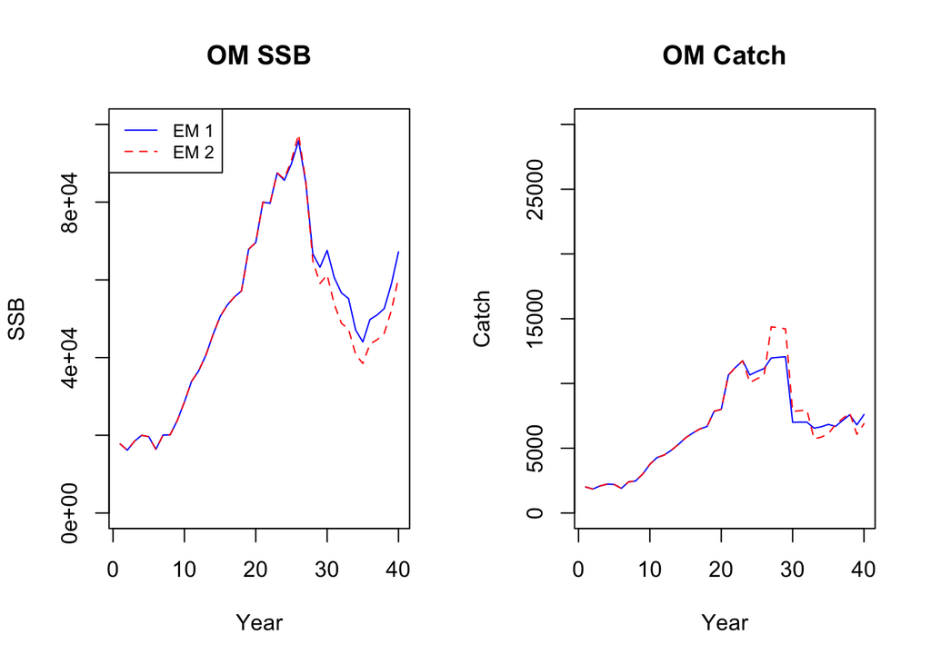

```r
par(mfrow = c(1,2))
SSB_s1 <- lapply(mods, function(mod) mod$om$rep$SSB[,1])
plot(SSB_s1[[1]], type = "l", col = "blue", ylab = "SSB", xlab = "Year", ylim=c(0,100000), main = "OM SSB")
colors <- c("red","green","purple","orange")
for (i in length(SSB_s1)) {
  lines(SSB_s1[[i]], col = colors[i-1],lty = i)
}
legend("topleft",legend = paste0("EM ", 1:2), col = c("blue",colors),lty=1:5, cex=0.8)

Catch_s1 <- lapply(mods, function(mod) mod$om$rep$pred_catch[,1])
plot(Catch_s1[[1]], type = "l", col = "blue", ylab = "Catch", xlab = "Year", ylim=c(0,30000), main = "OM Catch")
colors <- c("red","green","purple","orange")
for (i in length(Catch_s1)) {
  lines(Catch_s1[[i]], col = colors[i-1],lty = i)
}
```

Now add the one with no survey, from Cheng’s code

```r
# ---------------------------------
# Actually the above section (CV and Neff) will be useless because we will not have survey data in the feedback period), see code below:
# ---------------------------------
remove_agg = TRUE # remove a aggregate index for some years
remove_agg_pointer = 1 # target on index 1
remove_agg_years = 21:40 # all feedback years
remove_paa = TRUE # Also remove age comp for that index
remove_paa_pointer = 1 # target on index 1
remove_paa_years = 21:40 # all feedback years

input <- update_input_index_info(input, agg_index_sigma, index_Neff,
                                 remove_agg, remove_agg_pointer, remove_agg_years,
                                 remove_paa, remove_paa_pointer, remove_paa_years) # Update input file
```

Generate new om and dataset, keep same assessment interval as above

```r
om <- fit_wham(input, do.fit = F, do.brps = T, MakeADFun.silent = TRUE)
om_with_data <- update_om_fn(om, seed = 123, random = random)
```

```
##
## Now simulating data
```

Run new loop

```r
# this simulation actually represents the data-missing scenario.
mods[[3]] = loop_through_fn(om = om_with_data,
                            em_info = info,
                            random = random,
                            M_em = M, # use OM M
                            sel_em = sel, # use OM sel
                            NAA_re_em = NAA_re_em, # use rec assumed random around the mean instead, help runtime (est B-H is difficult)
                            move_em = NULL,
                            age_comp_em = "multinomial",
                            # Here is the correct code: separate.em = FALSE also works for one-area model
                            em.opt = list(separate.em = FALSE, separate.em.type = 1,
                                          do.move = FALSE, est.move = FALSE),
                            assess_years = assess.years,
                            assess_interval = assess.interval,
                            base_years = base.years,
                            year.use = 20, # number of years of data you want to use in the assessment model
                            add.years = TRUE,
                            # Must have the below code! Otherwise the EM will assume a constant CV and Neff (same as the CV and Neff in the first year) for the survey
                            update_index_info  = list(agg_index_sigma = agg_index_sigma, index_Neff = index_Neff), # Must have this!
                            seed = 123,
                            save.sdrep = FALSE,
                            save.last.em = TRUE,
                            FXSPR_init = 0.01) # IMPORTANT!
```

[output not shown]

```
##
## Now checking convergence of assessment model...
##
## Assessment model is converged.
##
## Now generating catch advice...
##
## Harvest Control Rule type 1
```

```
## Catch Advice
##  6825.018 7217.153 7552.169
##
## Now calculating F at age in the OM given the catch advice...
##
## Now calculating fleet-specific F in year  21
##
## Fishing mortality is  0.117698
##
## Now updating F in OM for year  21
##
## Now simulating data for year  21
##
## Now projecting data for years after  21
##
## Now calculating fleet-specific F in year  22
##
## Fishing mortality is  0.1242346
##
## Now updating F in OM for year  22
##
## Now simulating data for year  22
##
## Now projecting data for years after  22
##
## Now calculating fleet-specific F in year  23
##
## Fishing mortality is  0.1191203
##
## Now updating F in OM for year  23
##
## Now simulating data for year  23
##
## Now projecting data for years after  23
##
## Now conducting stock assessment for year 23
## [1] "start"
## [1] "basic_info"
## [1] "catch"
## [1] "indices"
```

[output cut: 20 more lines]

[output not shown]

```
##
## Now checking convergence of assessment model...
##
## Assessment model is converged.
##
## Now generating catch advice...
##
## Harvest Control Rule type 1
```

```
## Catch Advice
##  6813.065 6999.209 7162.135
##
## Now calculating F at age in the OM given the catch advice...
##
## Now calculating fleet-specific F in year  24
##
## Fishing mortality is  0.1101755
##
## Now updating F in OM for year  24
##
## Now simulating data for year  24
##
## Now projecting data for years after  24
##
## Now calculating fleet-specific F in year  25
##
## Fishing mortality is  0.1093194
##
## Now updating F in OM for year  25
##
## Now simulating data for year  25
##
## Now projecting data for years after  25
##
## Now calculating fleet-specific F in year  26
##
## Fishing mortality is  0.1073231
##
## Now updating F in OM for year  26
##
## Now simulating data for year  26
##
## Now projecting data for years after  26
##
## Now conducting stock assessment for year 26
## [1] "start"
## [1] "basic_info"
## [1] "catch"
## [1] "indices"
```

[output cut: 20 more lines]

[output not shown]

```
##
## Now checking convergence of assessment model...
##
## Assessment model is converged.
##
## Now generating catch advice...
##
## Harvest Control Rule type 1
```

```
## Catch Advice
##  8224.687 8277.993 8314.785
##
## Now calculating F at age in the OM given the catch advice...
##
## Now calculating fleet-specific F in year  27
##
## Fishing mortality is  0.1388234
##
## Now updating F in OM for year  27
##
## Now simulating data for year  27
##
## Now projecting data for years after  27
##
## Now calculating fleet-specific F in year  28
##
## Fishing mortality is  0.1766759
##
## Now updating F in OM for year  28
##
## Now simulating data for year  28
##
## Now projecting data for years after  28
##
## Now calculating fleet-specific F in year  29
##
## Fishing mortality is  0.1903613
##
## Now updating F in OM for year  29
##
## Now simulating data for year  29
##
## Now projecting data for years after  29
##
## Now conducting stock assessment for year 29
## [1] "start"
## [1] "basic_info"
## [1] "catch"
## [1] "indices"
```

[output cut: 20 more lines]

[output not shown]

```
##
## Now checking convergence of assessment model...
##
## Assessment model is converged.
##
## Now generating catch advice...
##
## Harvest Control Rule type 1
```

```
## Catch Advice
##  6963.423 7012.472 7015.432
##
## Now calculating F at age in the OM given the catch advice...
##
## Now calculating fleet-specific F in year  30
##
## Fishing mortality is  0.1585634
##
## Now updating F in OM for year  30
##
## Now simulating data for year  30
##
## Now projecting data for years after  30
##
## Now calculating fleet-specific F in year  31
##
## Fishing mortality is  0.1887487
##
## Now updating F in OM for year  31
##
## Now simulating data for year  31
##
## Now projecting data for years after  31
##
## Now calculating fleet-specific F in year  32
##
## Fishing mortality is  0.2151328
##
## Now updating F in OM for year  32
##
## Now simulating data for year  32
##
## Now projecting data for years after  32
##
## Now conducting stock assessment for year 32
## [1] "start"
## [1] "basic_info"
## [1] "catch"
## [1] "indices"
```

[output cut: 20 more lines]

[output not shown]

```
##
## Now checking convergence of assessment model...
##
## Assessment model is converged.
##
## Now generating catch advice...
##
## Harvest Control Rule type 1
```

```
## Catch Advice
##  4737.787 4823.624 4949.59
##
## Now calculating F at age in the OM given the catch advice...
##
## Now calculating fleet-specific F in year  33
##
## Fishing mortality is  0.1568905
##
## Now updating F in OM for year  33
##
## Now simulating data for year  33
##
## Now projecting data for years after  33
##
## Now calculating fleet-specific F in year  34
##
## Fishing mortality is  0.1865
##
## Now updating F in OM for year  34
##
## Now simulating data for year  34
##
## Now projecting data for years after  34
##
## Now calculating fleet-specific F in year  35
##
## Fishing mortality is  0.2080018
##
## Now updating F in OM for year  35
##
## Now simulating data for year  35
##
## Now projecting data for years after  35
##
## Now conducting stock assessment for year 35
## [1] "start"
## [1] "basic_info"
## [1] "catch"
## [1] "indices"
```

[output cut: 20 more lines]

[output not shown]

```
##
## Now checking convergence of assessment model...
##
## Assessment model is converged.
##
## Now generating catch advice...
##
## Harvest Control Rule type 1
```

```
## Catch Advice
##  3061.294 3337.497 3616.335
##
## Now calculating F at age in the OM given the catch advice...
##
## Now calculating fleet-specific F in year  36
##
## Fishing mortality is  0.1175776
##
## Now updating F in OM for year  36
##
## Now simulating data for year  36
##
## Now projecting data for years after  36
##
## Now calculating fleet-specific F in year  37
##
## Fishing mortality is  0.1174388
##
## Now updating F in OM for year  37
##
## Now simulating data for year  37
##
## Now projecting data for years after  37
##
## Now calculating fleet-specific F in year  38
##
## Fishing mortality is  0.1172022
##
## Now updating F in OM for year  38
##
## Now simulating data for year  38
##
## Now projecting data for years after  38
## Please ignore Warning in check_projF(proj_mod).
## Total Runtime =  5.254552
```

Visualize 3 mods (modified from https://lichengxue.github.io/whamMSE/03.Management-Strategy-Evaluation.html#12_Compare_model_performance)

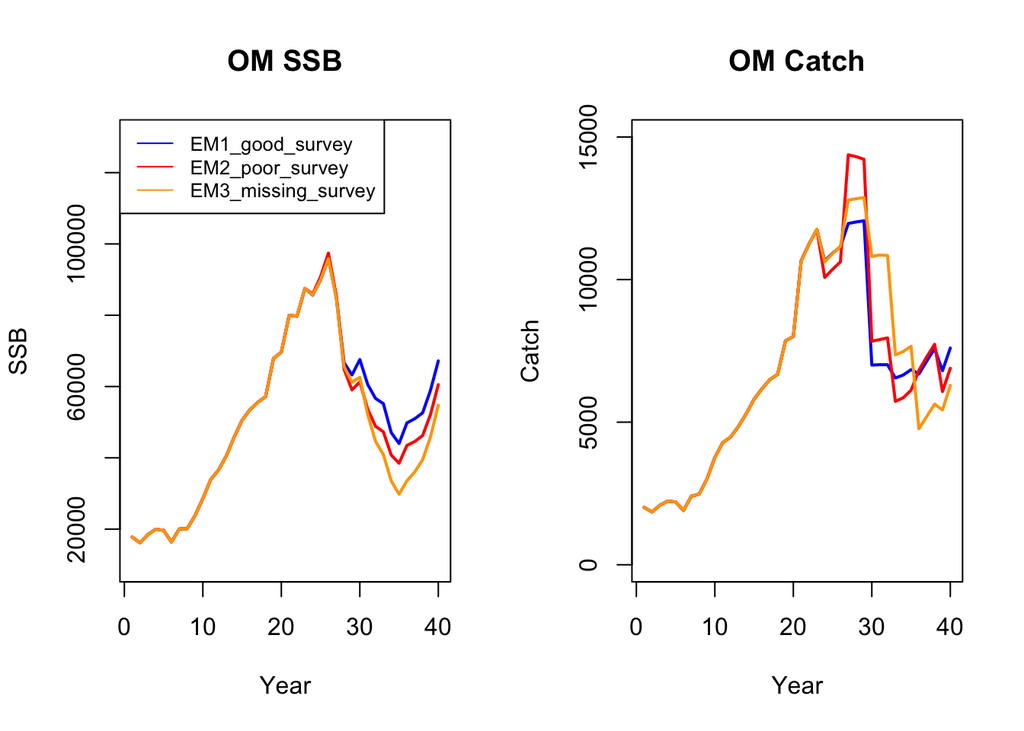

```r
par(mfrow = c(1,2))
SSB_s1 <- lapply(mods, function(mod) mod$om$rep$SSB[,1])
plot(SSB_s1[[1]], type = "l", col = "blue", ylab = "SSB", xlab = "Year", ylim=c(1e4,130000), main = "OM SSB",, lwd = 2)
lines(SSB_s1[[2]], col = "red",lty = 1, lwd = 2)
lines(SSB_s1[[3]], col = "orange",lty = 1, lwd = 2)

legend("topleft",legend = c("EM1_good_survey", "EM2_poor_survey","EM3_missing_survey"), col = c("blue","red","orange"),lty=1, cex=0.8)

Catch_s1 <- lapply(mods, function(mod) mod$om$rep$pred_catch[,1])
plot(Catch_s1[[1]], type = "l", col = "blue", ylab = "Catch", xlab = "Year", ylim=c(0,15000), main = "OM Catch", lwd = 2)
lines(Catch_s1[[2]], col = "red",lty = 1, lwd = 2)
lines(Catch_s1[[3]], col = "orange",lty = 1, lwd = 2)
```

# References

Wiedenmann, J., Wilberg, M., Sylvia, A., and Miller, T. 2017. An evaluation of acceptable biological catch (ABC) harvest control rules designed to limit overfishing. Canadian Journal of Fisheries and Aquatic Sciences **74**(7): 1028–1040. doi:10.1139/cjfas-2016-0381.